# detectRUNS: an R package to detect runs of homozygosity and heterozygosity in diploid genomes

Filippo Biscarini, Paolo Cozzi, Giustino Gaspa, Gabriele Marras

IBBA-CNR, PTP, Università degli Studi di Sassari, University of Guelph  
filippo.biscarini@ibba.cnr.it

2018-01-31

# Overview

**detectRUNS** is a R package for the detection of **runs of homozygosity** (**ROH/ROHom**) and of **heterozygosity** (**ROHet**, a.k.a. “**heterozygosity-rich regions**”) in diploid genomes. **ROH/ROHom** were first studied in humans (e.g. McQuillan et al. 2008) and rapidly found applications not only in human genetics abut also in animal genetics (e.g. Ferencakovic et al., 2011, in *Bos taurus*). More recently, the idea of looking also at “runs of heterozygosity” (**ROHet** or, more appropriately, “heterozygosity-rich regions”) has been proposed (Wiliams et al. 2016).

detectRUNS uses two methods to detect genomic runs:

1. sliding-window based method:
2. consecutive runs:

The sliding-window based method is similar to what is implemented in the computer package *Plink* (Purcell et al., 2007) [see Bjelland et al., 2013 for a description]. In brief, a sliding window is used to scan the genome, and the characteristics of consecutive windows are used to determine whether a SNP is or not in a run (either ROH/ROHom or ROHet). Parameters for both the sliding window and the run need to be specified.

The “consecutive runs” method is window-free and directly scans the genome SNP by SNP. It was first proposed by Marras et al. (2015). Here, only parameters for the runs need to be specified.

Besides detecting genomic runs (again, either homozygosity or heterozygosity, either sliding-window based or consecutive), and saving results to a data frame of individual runs, **detectRUNS** can:

- plot runs along the genome:
  - plot runs per individual
  - plot stacked (piled) runs
  - plot the % of times each SNP is in a run in the population (per chromosome)
  - Manhattan-like plot of the % of times each SNP is in a run
- plot mean or total run length vs number of runs per individual
- generate summary descriptive statistics on detected runs
- calculate inbreeding based on ROH (*$F_{ROH}$*), genome-wide and chromosome-wide
- plot $F_{ROH}$ per chromosome

The input files for **detectRUNS** are *Plink* **ped/map** files. If one wishes to use this R package only for plots and summary statistics, output files from *Plink* (.hom files) can be easily read into **detectRUNS** through a specific function.

**detectRUNS** can be used with genotype data from any diploid organisms: humans, animals or plants.

# Sample data

To illustrate the functionalities of **detectRUNS**, we use data on sheep (*Ovis aries*) SNP genotypes from the work by Kijas et al. (2016), available on-line through “Dryad” (https://goo.gl/sfAy8k). A subset with two breeds (“Jacobs” and “Navajo-Churro”, 100 animals) and two chromosomes ($4\,841$ SNPs from OAA 2 and 24) was used.

```r
genotypeFilePath <- system.file(
  "extdata", "Kijas2016_Sheep_subset.ped", package="detectRUNS")
mapFilePath <- system.file(
  "extdata", "Kijas2016_Sheep_subset.map", package="detectRUNS")
```

# Detect runs

For the detection of genomic runs, **detectRUNS** uses two main functions:

1. **slidingRUNS.run**: for sliding-window-based detection
2. **consecutiveRUNS.run**: for consecutive-SNP-based detection

Input files are to be passed as paths to files (e.g. /home/Documents/experiment/file.ped/map).

## sliding-window-based run detection

The function *slidingRUNS.run()* accepts in input several parameters: besides the paths (or names) of ped/map files, there are parameters related to the sliding window and parameters related to the genomic runs.

Sliding-window parameters are: *windowSize*, *threshold* (to call a SNP “in run”), *minSNP* (minimum number of homozygous/heterozygous SNP in the window), *maxOppWindow* (maximum number of SNP with opposite genotype: heterozygous/homozygous) and *maxMissWindow* (maximum number of missing genotypes).

Run-related parameters are: *maxGap* (maximum gap between consecutive SNPs, in basepairs -bps), *minLenghtBps* (minimum length of the run, in bps), *minDensity* (number of SNPs every $x$ kilo-basepairs -kbps), *maxOppRun* (maximum number of opposite genotypes in the run), *maxMissRun* (maximum number of missing genotypes in the run).

*ROHet* controls whether runs of homozygosity (ROH/ROHom) or of heterozygosity (heterozygosity-rich regions, ROHet) will be detected. It defaults to **FALSE** (ROH/ROHom).

```r
slidingRuns <- slidingRUNS.run(
  genotypeFile = genotypeFilePath,
  mapFile = mapFilePath,
  windowSize = 15,
  threshold = 0.05,
  minSNP = 20,
  ROHet = FALSE,
  maxOppWindow = 1,
  maxMissWindow = 1,
  maxGap = 10^6,
  minLengthBps = 250000,
  minDensity = 1/10^3, # SNP/kbps
  maxOppRun = NULL,
  maxMissRun = NULL
)
```

## consecutive SNP-based run detection

The function *consecutiveRUNS.run()* has a similar structure, obviously without the sliding-window parameters.

```r
consecutiveRuns <- consecutiveRUNS.run(
  genotypeFile =genotypeFilePath,
  mapFile = mapFilePath,
  minSNP = 20,
  ROHet = FALSE,
  maxGap = 10^6,
  minLengthBps = 250000,
  maxOppRun = 1,
  maxMissRun = 1
)
```

*slidingRUNS.run()* detected **1348** ROH; *consecutiveRUNS.run()* detected **1144** ROH.

## “Runs of heterozygosity” (a.k.a. heterozygosity-rich regions)

By setting **ROHet=TRUE**, runs of heterozygosity (a.k.a. heterozygosity-rich genomic regions) are detected instead. Again, the usert can choose whether to use the sliding-window or the consecutive method.

```r
slidingRuns_het <- slidingRUNS.run(
  genotypeFile = genotypeFilePath,
  mapFile = mapFilePath,
  windowSize = 10,
  threshold = 0.05,
  minSNP = 10,
  ROHet = TRUE,
  maxOppWindow = 2,
  maxMissWindow = 1,
  maxGap = 10^6,
  minLengthBps = 10000,
  minDensity = 1/10^6, # SNP/kbps
  maxOppRun = NULL,
  maxMissRun = NULL
)
```

```r
consecutiveRuns_het <- consecutiveRUNS.run(
  genotypeFile =genotypeFilePath,
  mapFile = mapFilePath,
  minSNP = 10,
  ROHet = TRUE,
  maxGap = 10^6,
  minLengthBps = 10000,
  maxOppRun = 2,
  maxMissRun = 1
)
```

*slidingRUNS.run()* detected **2297** ROHet; *consecutiveRUNS.run()* detected **1870** ROHet.

Runs of homozygosity (ROH) detected using the sliding-windows method (output from *slidingRUNS.run()*) will be used to illustrate summary statistics, plots and inbreeding calculations.

# Summary statistics on detected runs

The function *summaryRuns()* takes in input the dataframe with results from runs detection and calculates a number of basic descriptive statistics on runs. Additional necessary parameters are the paths to the *Plink* ped and map files. `Class` and `snpInRuns` are optional arguments.

```r
summaryList <- summaryRuns(
  runs = slidingRuns, mapFile = mapFilePath, genotypeFile = genotypeFilePath,
  Class = 6, snpInRuns = TRUE)
```

The returned list includes the following dataframes:

summary_ROH_count_chr, summary_ROH_percentage_chr, summary_ROH_count, summary_ROH_percentage, summary_ROH_mean_chr, summary_ROH_mean_class, result_Froh_genome_wide, result_Froh_chromosome_wide, result_Froh_class, SNPinRun

We can, for instance, have a look at the number of runs per class-size (Mbps) in the two breeds: we see that in Jacobs sheep there are 894 ROH with size up to 6 Mbps.

```r
summaryList$summary_ROH_count
```

```
##       Jacobs Navajo-Churro
## 0-6      894           260
## 6-12     101            20
## 12-24     34            12
## 24-48     14             7
## >48        3             3
```

Or, the average number of ROH per chromosome and per breed can be obtained.

```r
summaryList$summary_ROH_mean_chr
```

```
##   chrom   Jacobs Navajo-Churro
## 1     2 4.069597      4.492243
## 2    24 3.697987      2.745963
```

The dataframe “SNPinRun” contains, for each SNP, the proportion of times it falls inside a run in any given population/group:

```r
head(summaryList$SNPinRun)
```

```
##   SNP_NAME CHR POSITION COUNT  BREED PERCENTAGE
## 1 s47174.1   2   158066    11 Jacobs    17.1875
## 2 s30876.1   2   167018    11 Jacobs    17.1875
## 3 s16671.1   2   354035    12 Jacobs    18.7500
## 4 s31991.1   2   544617    12 Jacobs    18.7500
## 5 s33481.1   2   679324    12 Jacobs    18.7500
## 6 s49858.1   2   901838    12 Jacobs    18.7500
```

The summary information included in the list returned from *summaryRuns()* is conveniently organized in data.frames, so that it can easily be visualized, manipulated and written out to text files (e.g. .csv files).

# Plots

**detectRUNS** produces a number of plots from the dataframe with runs (results from sliding-window or consecutive scans of the genome for ROH/ROHet).

The basic plot, produced by the function *plot_Runs()*, plots directly all runs detected in each individual against their position along the chromosome. Separate plots per chromosome are produced, and different groups/populations are coloured differently to visualize contrasting patterns.

[figure not shown]

[figure not shown]

```r
plot_Runs(runs = slidingRuns)
```

Alternatively, runs can still be plotted against their position along the chromosome, but stacked on top of each other: this way, regions of the genome with an excesse of runs can easily be identified. In this case, separate plots per chromosome and per group/population are produced.

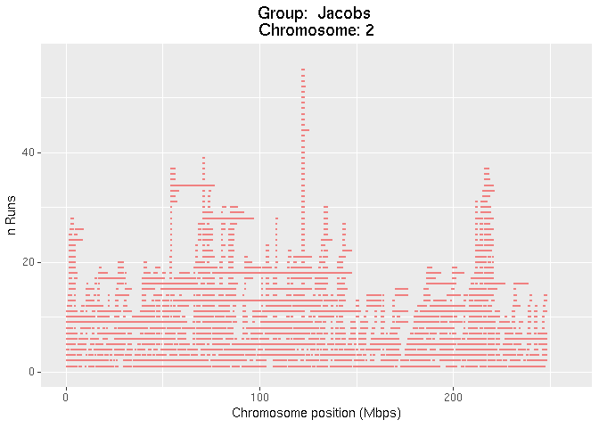

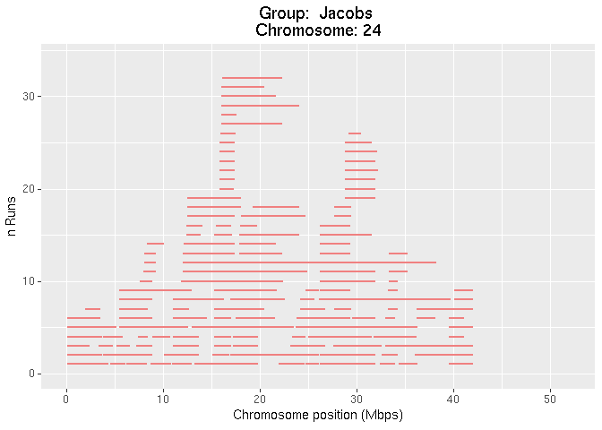

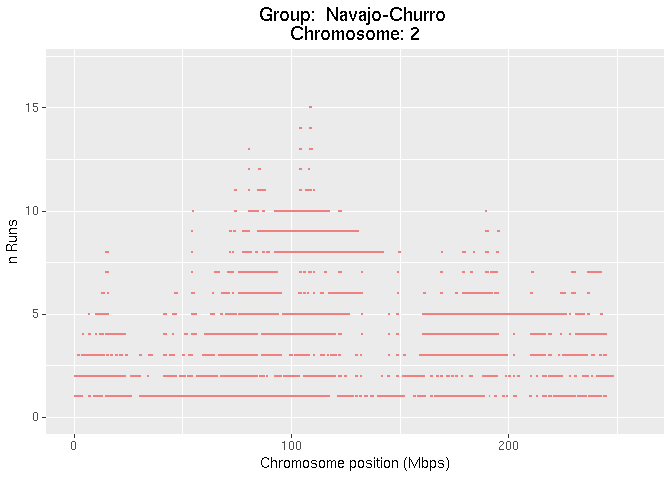

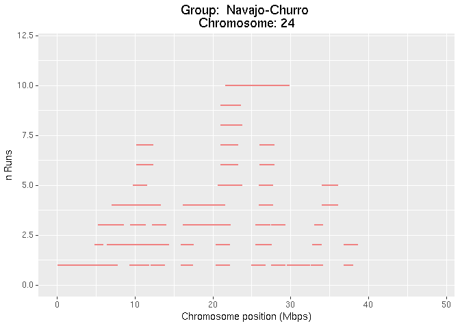

```r
plot_StackedRuns(runs = slidingRuns)
```

Finally, the proportion of times each SNP falls inside a run in any given population/group can be plotted against their position along the chromosome, separately per group. The function *plot_SnpsInRuns()* requires as arguments, besides the dataframe with detected runs, also the paths to the original ped (for information on groups) and map (for SNP positions) files.

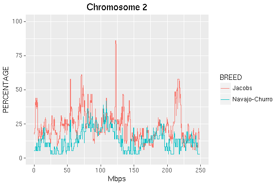

```r
plot_SnpsInRuns(
  runs = slidingRuns[slidingRuns$chrom==2,], genotypeFile = genotypeFilePath,
  mapFile = mapFilePath)
```

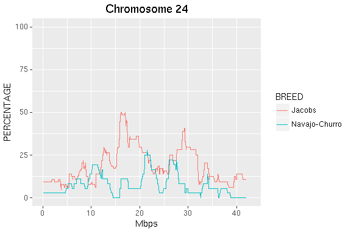

```r
plot_SnpsInRuns(
  runs = slidingRuns[slidingRuns$chrom==24,], genotypeFile = genotypeFilePath,
  mapFile = mapFilePath)
```

We can see from the plots above, that in the Jacob sheep breed a region with a “peakk”" of ROH can be spotted approximately halfway on chromosome 2 (OAR2) in the Jacob breed. This corresponds to the strong GWAS signals found by Kijas et al. (2016) on OAR2 associated with the four-horns phenotype.

To identify the position of a runs (ROH in this case) peak, e.g. from *plot_SnpsInRuns()*, one can conveniently use the function *detectRUNS::tableRuns()*: this requests as input, besides the runs dataframe, also the paths to the original ped/map files, and the threshold above which we want information on such “peaks” (e.g. only peaks where SNP are inside runs in more than 70% of the individuals in that population/group).

```r
topRuns <- tableRuns(
  runs =  slidingRuns, genotypeFile = genotypeFilePath, mapFile = mapFilePath,
  threshold = 0.7)
```

```
##    Group        Start_SNP          End_SNP chrom nSNP      from        to
## 1 Jacobs OAR2_130215973.1 OAR2_131721845.1     2   21 121796989 123528595
```

The information on the proportion of times each SNP falls inside a run, can also be plotted against SNP positions in all chromosomes together, similarly to the familiar GWAS **Manhattan plots**:

[figure not shown]

```r
plot_manhattanRuns(
  runs = slidingRuns[slidingRuns$group=="Jacobs",],
  genotypeFile = genotypeFilePath, mapFile = mapFilePath)
```

# $F_{ROH}$: ROH-based inbreeding

From runs of homozygosity (ROH), individual inbreeding/consanguinity coefficients can be calculated as:

$$F_{ROH} = \frac{\sum L_{ROH}}{L_{genome}}$$

where $\sum L_{ROH}$ is the sum of the length of all ROH detected in an individual, and $L_{genome}$ is the total length of the genome that was used.

**detectRUNS** provide functions to calculate individual inbreeding/consanguinity

[output not shown]

The parameter “genome_wide” (which defaults to TRUE) can be used to obtain inbreeding/consanguinity estimates on a per-chromosome basis (by setting “genome_wide=FALSE”)

Inbreeding levels can be plotted by group, for example:

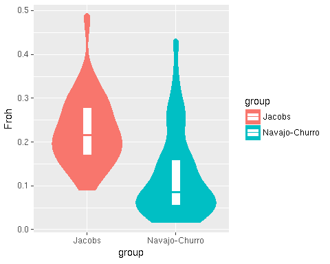

# Importing data from external files

Results on runs (typically ROH) from external software can be imported into **detectRUNS** to produce plots, tables and summary statistics. Current options include:

- ROH from **Plink** (.hom file from `--homozyg`)
- ROH from **BCFtools** (output from the `roh` option)
- runs dataframes from **detctRUNS** written out to files

Through the parameter `program` the user can select from which source the output file is coming. As an illustration, we read in results from *detectRUNS* saved out to a .csv file:

```r
savedRunFile <- system.file(
  "extdata", "Kijas2016_Sheep_subset.sliding.csv", package="detectRUNS")
runs <- readExternalRuns(inputFile = savedRunFile, program = "detectRUNS")
head(runs)
```

```
##    group   id chrom nSNP     from       to lengthBps
## 1 Jacobs H114     2   76  1606489  5215635   3609146
## 2 Jacobs H114     2   44  5798140  8518359   2720219
## 3 Jacobs H114     2  148 21979508 30849683   8870175
## 4 Jacobs H114     2   45 35582012 38744795   3162783
## 5 Jacobs H114     2   15 39198369 40023789    825420
## 6 Jacobs H114     2   16 52327990 53043790    715800
```

# References

- Bjelland, D. W., K. A. Weigel, N. Vukasinovic, and J. D. Nkrumah. “Evaluation of inbreeding depression in Holstein cattle using whole-genome SNP markers and alternative measures of genomic inbreeding.” journal of dairy Science 96, no. 7 (2013): 4697-4706.
- Ferencakovic, Maja, Edin Hamzic, Birgit Gredler, Ino Curik, and Johann Sölkner. “Runs of homozygosity reveal genome-wide autozygosity in the Austrian Fleckvieh cattle.” Agriculturae Conspectus Scientificus (ACS) 76, no. 4 (2011): 325-329.
- Kijas, James W., Tracy Hadfield, Marina Naval Sanchez, and Noelle Cockett. “Genome‐wide association reveals the locus responsible for four‐horned ruminant.” Animal genetics 47, no. 2 (2016): 258-262.
- Marras, Gabriele, Giustino Gaspa, Silvia Sorbolini, Corrado Dimauro, Paolo Ajmone‐Marsan, Alessio Valentini, John L. Williams, and Nicolò PP Macciotta. “Analysis of runs of homozygosity and their relationship with inbreeding in five cattle breeds farmed in Italy.” Animal genetics 46, no. 2 (2015): 110-121.
- McQuillan, Ruth, Anne-Louise Leutenegger, Rehab Abdel-Rahman, Christopher S. Franklin, Marijana Pericic, Lovorka Barac-Lauc, Nina Smolej-Narancic et al. “Runs of homozygosity in European populations.” The American Journal of Human Genetics 83, no. 3 (2008): 359-372.
- Purcell, Shaun, Benjamin Neale, Kathe Todd-Brown, Lori Thomas, Manuel AR Ferreira, David Bender, Julian Maller et al. “PLINK: a tool set for whole-genome association and population-based linkage analyses.” The American Journal of Human Genetics 81, no. 3 (2007): 559-575.
- Williams, John L., Stephen JG Hall, Marcello Del Corvo, K. T. Ballingall, L. I. C. I. A. Colli, P. A. O. L. O. Ajmone Marsan, and F. Biscarini. “Inbreeding and purging at the genomic Level: the Chillingham cattle reveal extensive, non‐random SNP heterozygosity.” Animal genetics 47, no. 1 (2016): 19-27.